# Troudt_A4_ISQA_8080

Eric Troudt

November 11, 2019

## PART 1

**a.** In this context, a hyperplane consists of a subspace with its number of dimensions determined by 1 - # of predictors. Its purpose is to optimally separate positive and negative training observations in a given data-set, thereby allowing for classifications of test observations into one of the two groups based on which side of the hyperplane it resides.

**b.** *Maximum Margin Classifiers*: Can only be applied if there is perfect separation of positive and negative observations within the training set. In this case, the hyperplane splits the separation of the positive and negative classes so that the margin, or minimal distance to the observations, is maximized (maximum margin).

*Support Vector Classifiers*: When perfect separation between classes is not possible, a support vector classifier can be used instead. Unlike maximum margin classifiers, support vector classifiers permit certain observations to violate, or have a shorter distance, than the margin, or even fall on the wrong side of the hyperplane. The number of observations, along with their degree of violation, are controlled by the tuning parameter C, which can be adjusted to balance the bias-variance trade-off.

*Support Vector Classifiers*: In cases where the hyperplane dividing the two classes is not linear, support vector machines can be used to generate non-linear decision boundaries for classes by implementing various polynomial, radial, or otherwise non-linear kernels for quantifying the similarity between training observations. According to the textbook, a given kernel will be applied to the inner products for all pairs of training observations, providing for a computationally efficient way to enlarge the feature space and drastically improve the accuracy of the classifications in ways linear hyperplanes cannot.

### **Data Prep**

```
## 'data.frame':    699 obs. of  10 variables:
##  $ clump.thickness      : int  5 5 3 6 4 8 1 2 2 4 ...
##  $ uniformity.cell.size : int  1 4 1 8 1 10 1 1 1 2 ...
##  $ uniformity.cell.shape: int  1 4 1 8 1 10 1 2 1 1 ...
##  $ marginal.adhesion    : int  1 5 1 1 3 8 1 1 1 1 ...
##  $ epithelial.cell.size : int  2 7 2 3 2 7 2 2 2 2 ...
##  $ bare.nuclei          : Factor w/ 11 levels "?","1","10","2",..: 2 3 4 6 2 3 3 2 2 2 ...
##  $ bland.chromatin      : int  3 3 3 3 3 9 3 3 1 2 ...
##  $ normal.nucleoli      : int  1 2 1 7 1 7 1 1 1 1 ...
##  $ mitoses              : int  1 1 1 1 1 1 1 1 5 1 ...
##  $ class                : Factor w/ 2 levels "Benign","Malignant": 1 1 1 1 1 2 1 1 1 1 ...
```

```
##  clump.thickness  uniformity.cell.size uniformity.cell.shape
##  Min.   : 1.000   Min.   : 1.000       Min.   : 1.000
##  1st Qu.: 2.000   1st Qu.: 1.000       1st Qu.: 1.000
##  Median : 4.000   Median : 1.000       Median : 1.000
##  Mean   : 4.418   Mean   : 3.134       Mean   : 3.207
##  3rd Qu.: 6.000   3rd Qu.: 5.000       3rd Qu.: 5.000
##  Max.   :10.000   Max.   :10.000       Max.   :10.000
##
##  marginal.adhesion epithelial.cell.size  bare.nuclei  bland.chromatin
##  Min.   : 1.000    Min.   : 1.000       1      :402   Min.   : 1.000
##  1st Qu.: 1.000    1st Qu.: 2.000       10     :132   1st Qu.: 2.000
##  Median : 1.000    Median : 2.000       2      : 30   Median : 3.000
##  Mean   : 2.807    Mean   : 3.216       5      : 30   Mean   : 3.438
##  3rd Qu.: 4.000    3rd Qu.: 4.000       3      : 28   3rd Qu.: 5.000
##  Max.   :10.000    Max.   :10.000       8      : 21   Max.   :10.000
##                                         (Other): 56
##  normal.nucleoli     mitoses             class
##  Min.   : 1.000   Min.   : 1.000   Benign   :458
##  1st Qu.: 1.000   1st Qu.: 1.000   Malignant:241
##  Median : 1.000   Median : 1.000
##  Mean   : 2.867   Mean   : 1.589
##  3rd Qu.: 4.000   3rd Qu.: 1.000
##  Max.   :10.000   Max.   :10.000
##
```

**c.**

## **Linear SVM Model**

```
## Support Vector Machine object of class "ksvm"
##
## SV type: C-svc  (classification)
##  parameter : cost C = 1
##
## Linear (vanilla) kernel function.
##
## Number of Support Vectors : 44
##
## Objective Function Value : -32.1112
## Training error : 0.026531
## Probability model included.
```

### **Linear SVM - Test data Confusion Matrix/Statistics/ROC**

```
## Confusion Matrix and Statistics
##
##           Reference
## Prediction Yes  No
##        Yes  68   3
##        No    4 134
##
##                Accuracy : 0.9665
##                  95% CI : (0.9322, 0.9864)
##     No Information Rate : 0.6555
##     P-Value [Acc > NIR] : <2e-16
##
##                   Kappa : 0.9256
##
##  Mcnemar's Test P-Value : 1
##
##             Sensitivity : 0.9444
##             Specificity : 0.9781
##          Pos Pred Value : 0.9577
##          Neg Pred Value : 0.9710
##              Prevalence : 0.3445
##          Detection Rate : 0.3254
##    Detection Prevalence : 0.3397
##       Balanced Accuracy : 0.9613
##
##        'Positive' Class : Yes
##
```

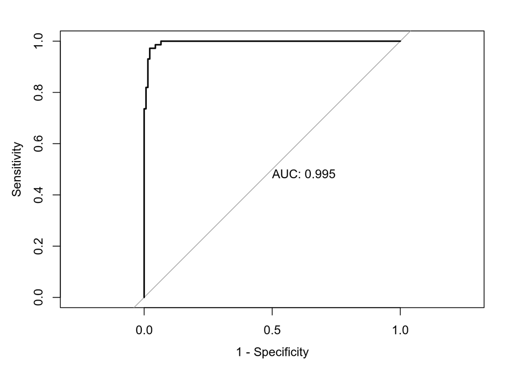

```
## Area under the curve: 0.9953
```

## **Linear SVM Model with C parameter tuning**

```
## Support Vector Machine object of class "ksvm"
##
## SV type: C-svc  (classification)
##  parameter : cost C = 0.01
##
## Linear (vanilla) kernel function.
##
## Number of Support Vectors : 92
##
## Objective Function Value : -0.66
## Training error : 0.030612
## Probability model included.
```

### **Linear SVM with C parameter tuning - Test data Confusion Matrix/Statistics/ROC**

```
## Confusion Matrix and Statistics
##
##           Reference
## Prediction Yes  No
##        Yes  68   4
##        No    4 133
##
##                Accuracy : 0.9617
##                  95% CI : (0.926, 0.9833)
##     No Information Rate : 0.6555
##     P-Value [Acc > NIR] : <2e-16
##
##                   Kappa : 0.9152
##
##  Mcnemar's Test P-Value : 1
##
##             Sensitivity : 0.9444
##             Specificity : 0.9708
##          Pos Pred Value : 0.9444
##          Neg Pred Value : 0.9708
##              Prevalence : 0.3445
##          Detection Rate : 0.3254
##    Detection Prevalence : 0.3445
##       Balanced Accuracy : 0.9576
##
##        'Positive' Class : Yes
##
```

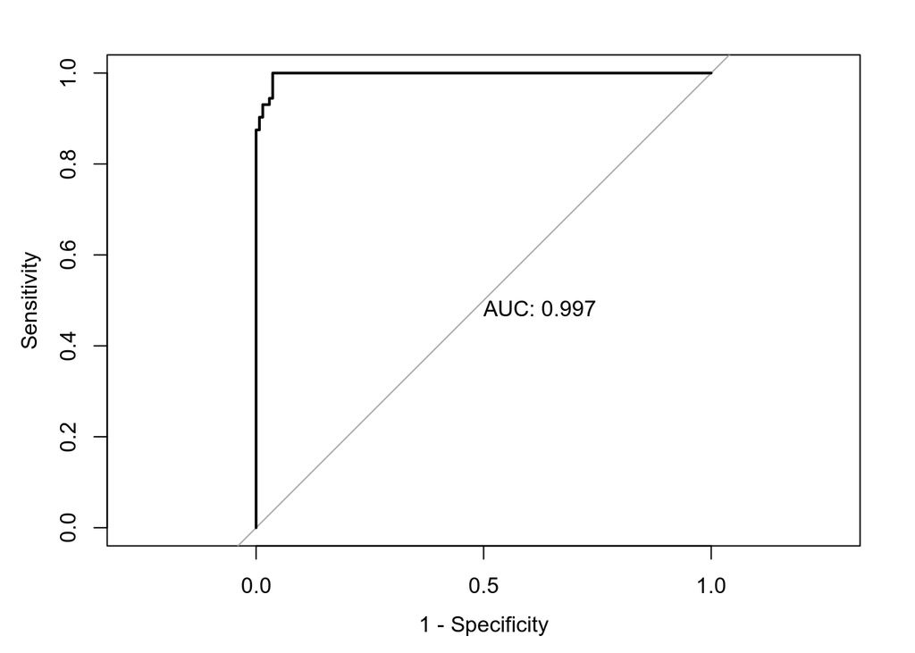

```
## Area under the curve: 0.997
```

**d.** Based off the performance metrics above for the predictions of the test data for both the default linear svm (C = 1) and the linear svm with C Parameter tuning (C = 0.01 or 0.001), neither model consistently outperforms the other. Depending on the particular instance of the two models, one may exhibit a slightly higher value for accuracy, kappa, or sensitivity, but otherwise the two models have near-equal performance in their ability to correctly identify malignant tumors (sensitivty) and avoiding misdiagnoses from false positives (specificity).

## **Radial SVM Model with C parameter tuning**

```
## Support Vector Machine object of class "ksvm"
##
## SV type: C-svc  (classification)
##  parameter : cost C = 5
##
## Gaussian Radial Basis kernel function.
##  Hyperparameter : sigma =  0.01
##
## Number of Support Vectors : 56
##
## Objective Function Value : -183.5993
## Training error : 0.02449
## Probability model included.
```

### **Radial SVM with C parameter tuning - Test data Confusion Matrix/Statistics/ROC**

```
## Confusion Matrix and Statistics
##
##           Reference
## Prediction Yes  No
##        Yes  69   4
##        No    3 133
##
##                Accuracy : 0.9665
##                  95% CI : (0.9322, 0.9864)
##     No Information Rate : 0.6555
##     P-Value [Acc > NIR] : <2e-16
##
##                   Kappa : 0.9261
##
##  Mcnemar's Test P-Value : 1
##
##             Sensitivity : 0.9583
##             Specificity : 0.9708
##          Pos Pred Value : 0.9452
##          Neg Pred Value : 0.9779
##              Prevalence : 0.3445
##          Detection Rate : 0.3301
##    Detection Prevalence : 0.3493
##       Balanced Accuracy : 0.9646
##
##        'Positive' Class : Yes
##
```

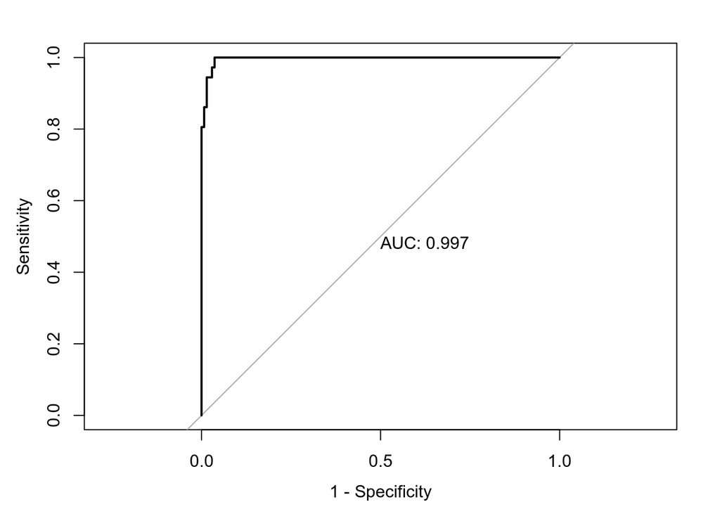

```
## Area under the curve: 0.9966
```

## PART 2

**a.** Both Ridge Regression and LASSO can reduce the variance of the beta parameter estimates of ordinary least squares (OLS). This is achieved by minimizing a modified form of the RSS (loss function) that includes an additional shrinkage penalty consisting of the product of a tuning parameter and the sum of either the square of each beta parameter (Ridge regression) or the absolute value of each beta parameter (Lasso). In both cases, as the tuning parameter is increased, the effect of the shrinkage penalty grows, and as a consequence the beta estimates are ‘shrunk’ or ‘regularized’ closer to zero. Shrinking beta parameters in this manner has the effect of slowly increasing the bias while significantly reducing the variance of the model. To revert back to OLS from either Ridge regression or LASSO, the tuning parameter simply needs to be set to zero, and thus the minimization process will focus solely on the RSS without any shrinkage penalty, which is what OLS does.

**b.** While both are effective at shrinking beta parameter estimates, the difference in the way the shrinkage penalties are calculated for each method leads to an important distinction: The l1 penalty of lasso permits setting beta estimates to 0, while the l2 penalty of Ridge will not, and therefore lasso can perform variable selection in addition to regularization.

**c** As the textbook demonstrates, Lasso will probably exhibit better model performance (in terms of test MSE) when only a small subset of predictors account for the variance of the response (high beta estimates), while the remaining predictors have little to no effect (extremely low beta estimates). Conversely, when the variance of the response is somewhat evenly distributed among all or most of the predictors (similar beta estimates), Ridge regression will likely perform better.

**d.**

### **Ridge regression on Ames Housing - Training data RMSE/Regularization parameter**

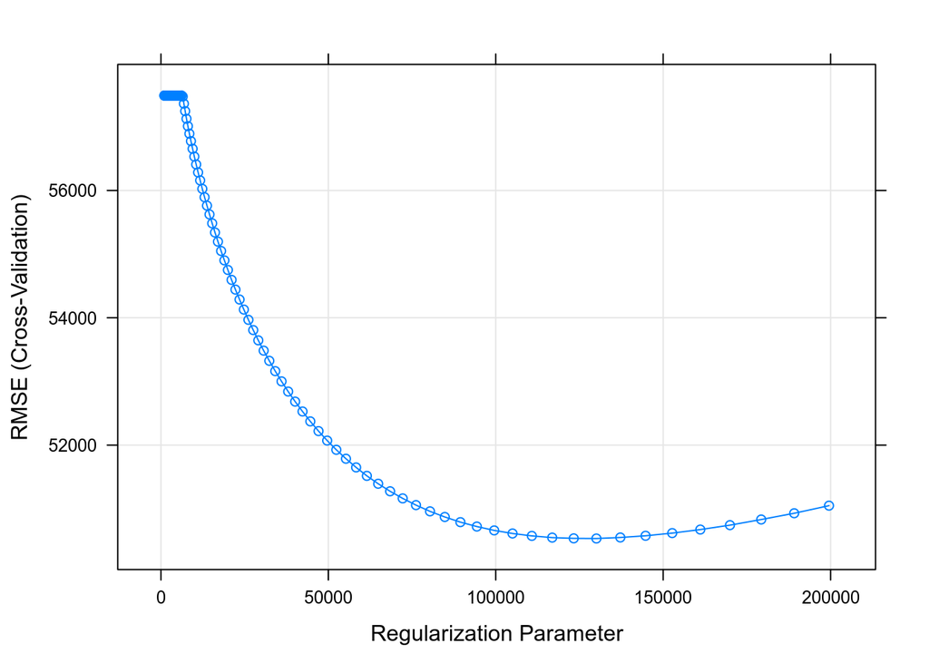

### **Ridge regression on Ames Housing - Test data predictions/RMSE**

```
##         RMSE     Rsquared          MAE
## 3.255643e+04 8.471324e-01 2.180597e+04
```

### **Lasso on Ames Housing - Training data RMSE/Regularization parameter/selected coefs**

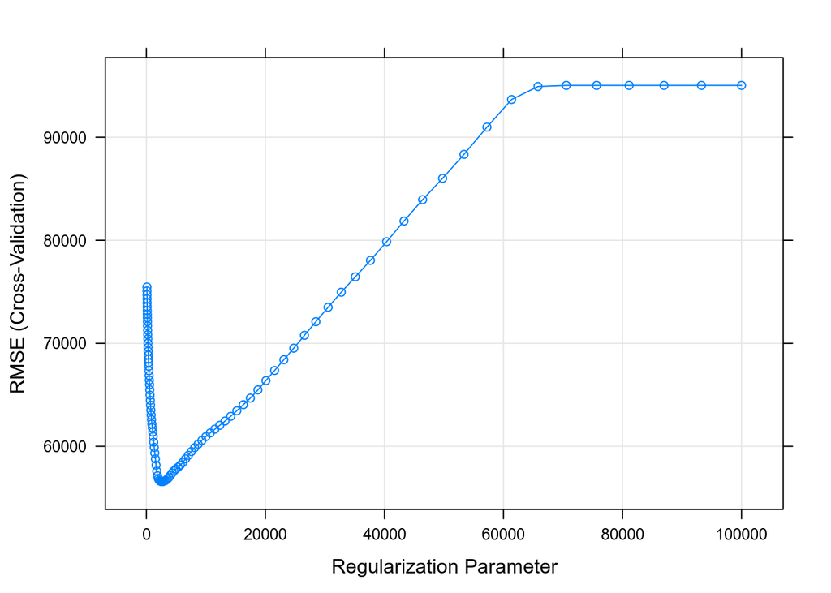

```
## 233 x 1 sparse Matrix of class "dgCMatrix"
##                                  1
## (Intercept)          225369.854015
## MSSubClass30              .
## MSSubClass40              .
## MSSubClass45              .
## MSSubClass50              .
## MSSubClass60              .
## MSSubClass70              .
## MSSubClass75              .
## MSSubClass80              .
## MSSubClass85              .
## MSSubClass90              .
## MSSubClass120             .
## MSSubClass160             .
## MSSubClass190             .
## MSZoningFV                .
## MSZoningRL                .
## MSZoningRM                .
## LotFrontage               .
## LotArea                7085.791803
## StreetPave                .
## LotShapeIR2               .
## LotShapeIR3           -6383.407858
## LotShapeReg               .
## LandContourHLS            .
## LandContourLow            .
## LandContourLvl          312.037067
## LotConfigCulDSac       6224.713649
## LotConfigFR2              .
## LotConfigFR3              .
## LotConfigInside           .
## LandSlopeMod              .
## LandSlopeSev              .
## NeighborhoodBlueste       .
## NeighborhoodBrDale        .
## NeighborhoodBrkSide       .
## NeighborhoodClearCr       .
## NeighborhoodCollgCr       .
## NeighborhoodCrawfor    2596.678291
```

[output cut: 180 more lines]

```
## PoolArea                  .
## MiscVal                   .
## MoSold                    .
## YrSold                    .
## SaleTypeCon               .
## SaleTypeConLD             .
## SaleTypeConLI             .
## SaleTypeConLw             .
## SaleTypeCWD               .
## SaleTypeNew            6091.898960
## SaleTypeWD                .
## SaleConditionAlloca     324.141475
## SaleConditionFamily   -1996.231709
## SaleConditionNormal       .
## SaleConditionPartial      4.959258
```

### **Lasso on Ames Housing - Test data predictions/RMSE**

```
##         RMSE     Rsquared          MAE
## 3.862321e+04 7.712525e-01 2.371206e+04
```

### **Linear regression with OLS on Ames Housing - Training data RMSE/Regularization parameter**

```
##         RMSE     Rsquared          MAE
## 1.508591e+05 1.784337e-01 6.072089e+04
```

**g.**

Compared with lasso and linear regression with OLS, Ridge Regression performed the best with the lowest RMSE and highest Rsquared value. The top 4 coefficients selected for the lasso model were OverallQual, GrLivArea, GarageCars, and RoofMatlWdShngl, but there are were still 100+ predictors included in the lasso model following feature selection. This indicates that the influence in the variance of sale price is pretty evenly distributed across most of the predictors, and explains why ridge regression outperforms lasso for the ames housing dataset.